# Mortality

In this section, we demonstrate the use of the arcsine, median, mode, cut, quotient, residual, influence, and miss data transformations to explore the World Health Organization’s data on mortality by country in 2009 and 2010. By applying each individual transformation or a combination of transformations, we can analyze the data in different ways, pulling new information each time.

**Arcsine Data Transformation**  
The arcsine data transformation is a widely used method of normalizing proportion data (data from 0 to 1) for linear regression. It is calculated as arcsin(sqrt(x)), where x is a vector of values between 0 and 1. Though the arcsine transformation is especially popular in the analysis of proportional data, it is a controversial method, and many have argued that the boxcox power transformation is a better alternative to the arcsine transformation.  
We demonstrate the arcsine transformation here in a visualization of the proportion of total deaths that occur in each age range (infant to elderly):

In the histogram and density distributions below, we can see that the post-transformation data has a more linear and normalized trend than the pre-transformation data.

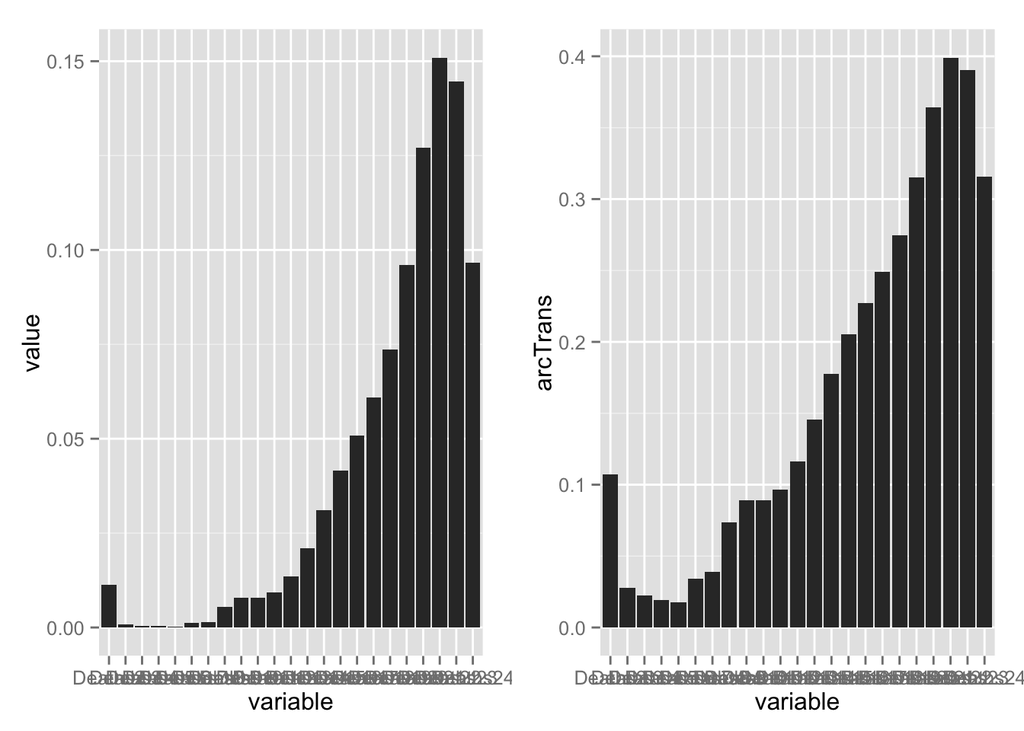

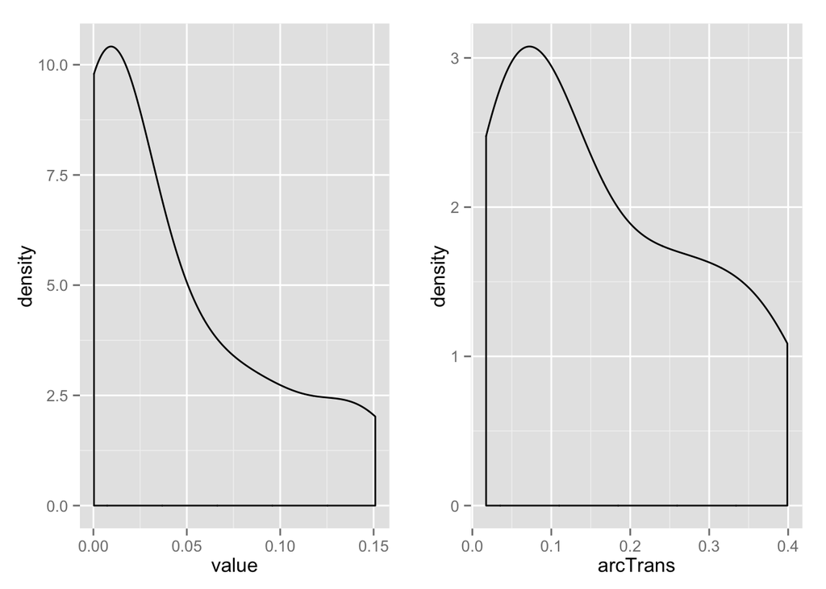

We can evaluate just how effective the arcsine data transformation was by running a robust linear regression on the data. Once the regresssion is fitted, we’ll use the *residual* and *influence* transformations to analyze each regression.

**Residual Data Transformation**  
The residual data transformation is used in conjunction with a linear regression on a set of data to calculate how much distance there is between each of the data values and the predicted regression values. While correlation coefficients are widely used to understand a model’s goodness of fit, residuals provide an effective way to visualize it - the larger the residuals, the farther the actual data points are the model, and thus, the less accurate the model.  
With the example of proportions of total deaths that occur in each age range, we ran a linear regression on the data before and after the arcsine transformation. We then calculated and plotted the residuals.

In these charts, we can see that the arcsin transformation did in fact improve the residuals and can be considered a useful tranformation for this data:

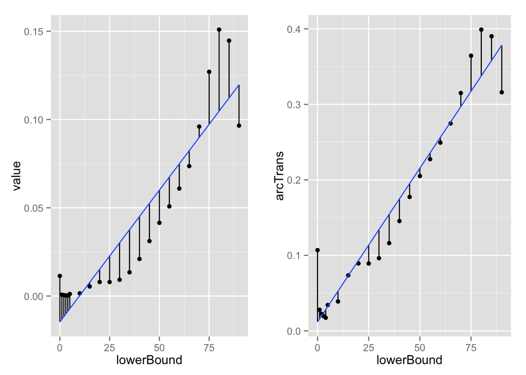

In the following visualizations, we can see that in post arcsine transformation, every data point increases the correlation of the regression model, indicating that the model is a relatively better fit than in the pre arcsine transformation, where some of the data points decrease the correlation.

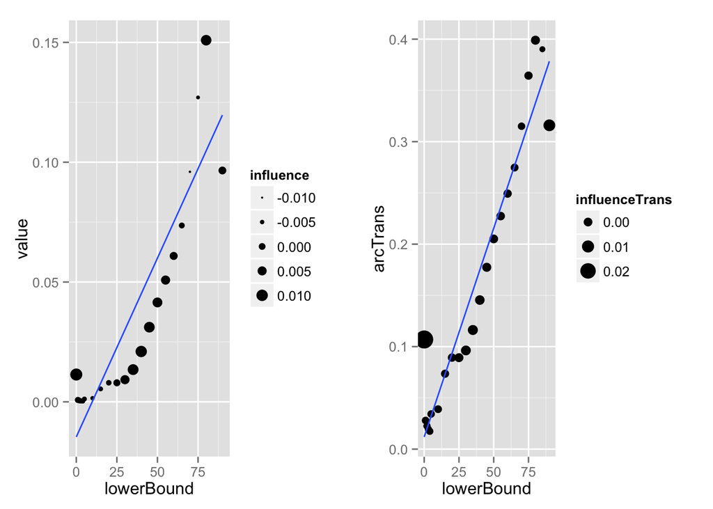

**The ‘Miss’ Data Transformation**  
The *miss()* transformation is used to impute missing data. This is to say, where data points are missing from a data set, *miss()* predicts what those values should be and fills them in. One of the most common ways to implement a *miss()* transformation is to run a regression and replace all NA values with the value predicted by the regression. The simplest form of this is to use a linear regression; however, there are other models that can help account for randomness in data by taking errors into account (see Gellman Ch 25). All values that were previously present remain unaltered.  
Here we run a *miss()* transformation on the Deaths24 variable, which contains roughly 15000 missing values, in order to reanalyze the proportions of death in each age range. By linearly regressing Deaths24 on Deaths2-Deaths23, we predict the values and impute into the missing data. The r^2 coefficient for this regression is .99, so we can assume that the predicted values should fit well. Once the values of Deaths24 are imputed, we finally recalculate the sum of total deaths to reconfigure the proportions.

As you can see, this alters the shape of the distribution and could cause one to question the validity of ommiting missing data in this case.

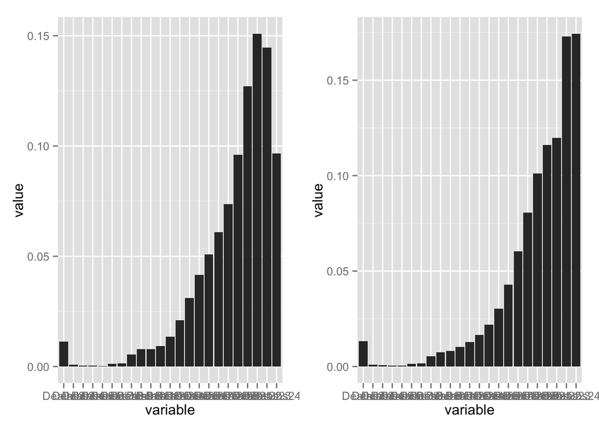

**Median Data Transformation** The median is one of the most commonly used properties of a data set. It describes the value that is positioned exactly in the middle of the set. The median is a valuable piece of data because it allows us to see the exact midpoint of a data set, at which 50% of the data falls below the median and 50% of the data lies above it. One key difference it has from the mean is that it is not effected by outliers.

In this application of the median, we look at the change in world infant mortality rate over time. This allows us to clearly visualize a decreasing trend in infant mortality rate over time, with key improvements coming at the year 2000.

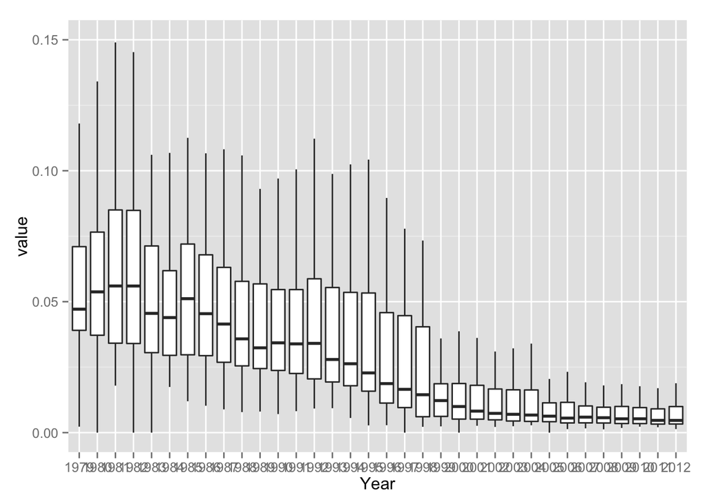

**Mode Data Transformation** The mode describes the data value that appears the most times in a data set. The mode is often helpful for identifying which value applies to the largest portion of at a data set. With the WHO mortality data, we looked at the death counts by age in each country and identified the age at which most of each country’s deaths occurred. We present the result as a heat map, with the hue representing the most common age-range of death in each country. This allows us to view geographic trends, such as in which countries the most common age of death is high and which are infant deaths. However, the most striking takeaway is the fact that the mode of South African mortality is 30-34.

```
## 125 codes from your data successfully matched countries in the map
## 5 codes from your data failed to match with a country code in the map
## 117 codes from the map weren't represented in your data
```

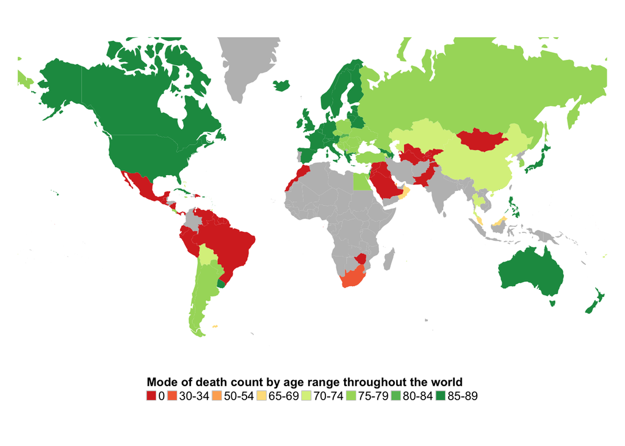

**Quotient Data Transformation**  
The *quotient(x1,x2)* data transformation divides elements in a vector x1 by its corresponding elements in another vector, x2. The vectors x1 and x2 must be the same length for the quotient function to be valid. Often, *quotient()* is used to find the number of items per category, for example, number of trees per square foot or number of computers per household. In the WHO data, we use the quotient function to find the infant mortality rate in each country by calculating:  
infant mortality rate = (number of infant deaths)/(total infant population)

**Cut Data Transformation**  
The cut data transformation takes sorted data and cuts it into n ranges of values. This is helpful for taking many values that may be difficult to compare and consolidating them into a small number of ranges that can hold more immediate meaning in a visualization. Here, we use the cut function to color countries in a heat map by which of four ranges of infant mortality rate values their infant mortality rate falls into.

```
## 120 codes from your data successfully matched countries in the map
## 4 codes from your data failed to match with a country code in the map
## 123 codes from the map weren't represented in your data
```

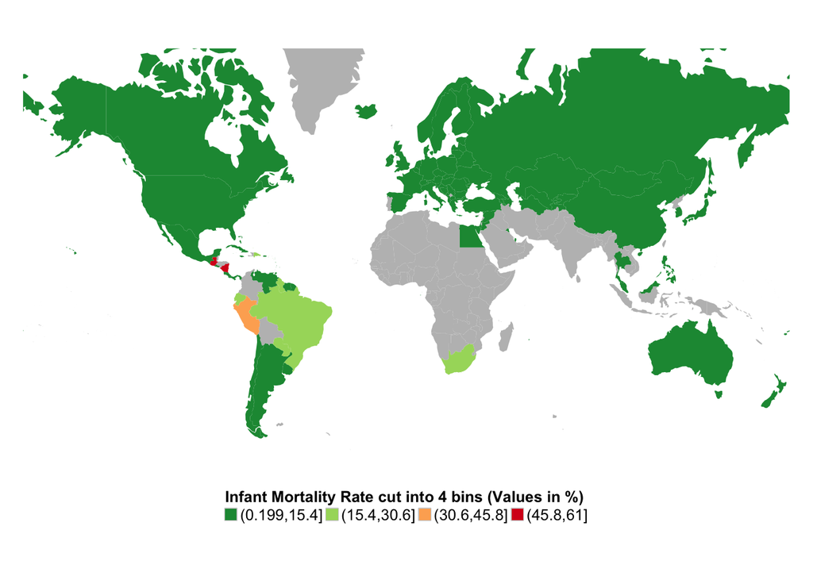